# 2020162222_통계학과_류태영_DRIP

202016222 통계학과 류태영

2025-10-31

```r
# ============================================================
# 📂 로또 데이터 통합 파이프라인 (lotto + rounds + place)
# ============================================================

# -----------------------------
# 1️⃣ 경로 지정
# -----------------------------
path_lotto  <- "C:/R study/html_lotto/home/kshan@jbnu.ac.kr/Data/lotto/html_lotto"
path_rounds <- "C:/R study/html_rounds/home/kshan@jbnu.ac.kr/Data/lotto/html_rounds"
path_place  <- "C:/R study/html_place/home/kshan@jbnu.ac.kr/Data/lotto/html_place"

# -----------------------------
# 2️⃣ 패키지 로드
# -----------------------------
library(rvest)
library(dplyr)
library(stringr)
library(tidyr)
library(lubridate)
library(readxl)
library(writexl)
library(ggplot2)
library(purrr)
library(tibble)
library(readr)
library(car)
library(e1071)
library(nortest)
library(scales)
library(knitr)
library(ineq)
library(furrr)
library(fuzzyjoin)
library(sf)
library(fitdistrplus)
library(spdep)
library(showtext)
font_add_google("Nanum Gothic", "nanumgothic")
showtext_auto()
library(httr)
library(jsonlite)
library(RSelenium)
# ============================================================
# 3️⃣ 기본 함수 (회차 파서)
# ============================================================
parse_round_from_filename <- function(fname) {
  m <- stringr::str_match(basename(fname), "^(\\d+)\\.html$")
  if (is.na(m[1,2])) NA_integer_ else as.integer(m[1,2])
}

# ============================================================
# 4️⃣ 로또 본문 파싱 함수
# ============================================================
parse_lotto_result_full <- function(file) {
  out <- tryCatch({
    html <- read_html(file, encoding = "UTF-8")
    round <- html %>%
      html_node(".win_result h4 strong") %>%
      html_text(trim = TRUE) %>%
      str_extract("\\d+") %>%
      as.integer()
    if (is.na(round)) round <- parse_round_from_filename(file)

    date_txt <- html %>% html_node(".win_result p.desc") %>% html_text(trim = TRUE)
    draw_date <- str_extract(date_txt, "\\d{4}년\\s*\\d{2}월\\s*\\d{2}일")

    nums <- html %>% html_nodes(".num.win span") %>% html_text(trim = TRUE) %>% as.integer()
    bonus <- html %>% html_nodes(".num.bonus span") %>% html_text(trim = TRUE) %>% as.integer()

    tb <- html %>% html_node("table.tbl_data_col") %>% html_table(fill = TRUE)
    tb <- tb %>% rename_with(~ str_squish(.x)) %>% mutate(across(everything(), str_squish))

    list_text <- html %>% html_nodes("ul.list_text_common li") %>% html_text(trim = TRUE)
    total_sales <- list_text %>% str_subset("총판매금액") %>% str_extract("[0-9,]+") %>%
      str_remove_all(",") %>% as.numeric()
    payment_due <- list_text[str_detect(list_text, "당첨금 지급기한")]

    parse_money <- function(x) x %>% str_replace_all("[^0-9]", "") %>% na_if("") %>% as.numeric()

    tb %>%
      mutate(
        round = round,
        draw_date = draw_date,
        total_sales = total_sales,
        payment_due = payment_due,
        n1 = nums[1], n2 = nums[2], n3 = nums[3],
        n4 = nums[4], n5 = nums[5], n6 = nums[6],
        bonus = bonus,
        등위별총당첨금액_num = parse_money(`등위별 총 당첨금액`),
        당첨게임수_num = parse_money(`당첨게임 수`),
        게임당당첨금_num = parse_money(`1게임당 당첨금액`)
      )
  }, error = function(e) tibble(round = parse_round_from_filename(file)))
  out
}

# ============================================================
# 5️⃣ 병합 빌더
# ============================================================
build_lotto_results_full <- function(root = path_lotto, parallel = TRUE) {
  files <- list.files(root, pattern = "\\.html$", full.names = TRUE)
  rounds <- as.integer(str_match(basename(files), "^(\\d+)\\.html$")[,2])
  files <- files[order(rounds)]

  if (parallel) {
    plan(multisession, workers = max(1, parallel::detectCores() - 1))
    df <- future_map_dfr(files, parse_lotto_result_full, .progress = TRUE)
    plan(sequential)
  } else df <- map_dfr(files, parse_lotto_result_full)
  df %>% arrange(round, 순위)
}

# ============================================================
# 6️⃣ 판매점 / 전국 판매점 파싱
# ============================================================
parse_round_shops_one_round <- function(dir_round) {
  round <- as.integer(str_match(basename(dir_round), "round_(\\d{4})")[,2])
  pages <- list.files(dir_round, pattern = "^page_\\d+\\.html$", full.names = TRUE)

  tb_all <- map_df(pages, function(p) {
    html <- read_html(p, encoding = "UTF-8")
    read_shop_table <- function(tbl, rank, round) {
      if (is.null(tbl)) return(tibble())
      df <- html_table(tbl, fill = TRUE)
      if (is.list(df)) df <- df[[1]]
      if (nrow(df) == 0) return(tibble())
      names(df) <- str_squish(names(df))
      df <- df %>% mutate(across(everything(), str_squish))
      col_shop   <- names(df)[str_detect(names(df), "상호|판매점|가맹점|점포|상호명")]
      col_addr   <- names(df)[str_detect(names(df), "소재지|주소")]
      col_method <- names(df)[str_detect(names(df), "구분|방식|자동|수동")]
      df %>% mutate(
        round = round,
        rank = rank,
        shop_name = if (length(col_shop)) .data[[col_shop[1]]] else NA,
        addr = if (length(col_addr)) .data[[col_addr[1]]] else NA,
        method = if (length(col_method)) .data[[col_method[1]]] else NA
      ) %>% select(round, rank, shop_name, addr, method)
    }

    tb_1 <- html %>% html_nodes("div.group_content") %>%
      keep(~ str_detect(html_text(.x), "1등 배출점")) %>%
      html_node("table.tbl_data_col") %>% read_shop_table("1등", round)
    tb_2 <- html %>% html_nodes("div.group_content") %>%
      keep(~ str_detect(html_text(.x), "2등 배출점")) %>%
      html_node("table.tbl_data_col") %>% read_shop_table("2등", round)
    bind_rows(tb_1, tb_2)
  })
  tb_all
}
build_round_shops <- function(root = path_rounds) {
  dirs <- list.dirs(root, recursive = FALSE, full.names = TRUE)
  bind_rows(map(dirs, parse_round_shops_one_round))
}

parse_place_dir <- function(dir_place) {
  region_dir <- basename(dir_place)
  pages <- list.files(dir_place, pattern = "^page_\\d+\\.html$", full.names = TRUE)
  bind_rows(map(pages, function(p) {
    html <- read_html(p, encoding = "UTF-8")
    region_text <- html %>% html_node("#searchResult") %>% html_text(trim = TRUE)
    if (!is.na(region_text) && str_detect(region_text, "\\s")) {
      parts <- str_split(region_text, "\\s+", simplify = TRUE)
      sido <- parts[,1]; gugun <- parts[,2]
    } else { sido <- region_text; gugun <- NA_character_ }
    tb <- html %>% html_node("table#resultTable") %>% html_table(fill = TRUE)
    tb %>% rename_with(str_squish) %>%
      mutate(across(everything(), str_squish)) %>%
      transmute(sido = sido, gugun = gugun,
                shop_name = `상호명`, tel = `전화번호`, addr = `소재지`)
  }))
}
build_place_master <- function(root = path_place) {
  dirs <- list.dirs(root, recursive = FALSE, full.names = TRUE)
  bind_rows(map(dirs, parse_place_dir))
}

# ============================================================
# 7️⃣ 실행 및 저장 (RAW + CLEANED) ###############필요시 주석 해제#############
# ============================================================

# ✅ 1) HTML 파싱 → 원본(raw) 데이터 저장 -
# lotto_raw  <- build_lotto_results_full(path_lotto, parallel = TRUE)
# shops_raw  <- build_round_shops(path_rounds)
# place_raw  <- build_place_master(path_place)

# 필요시 주석 해제
# write_csv(lotto_raw, "lotto_result_raw.csv")
# write_csv(shops_raw, "round_shops_raw.csv")
# write_csv(place_raw, "place_master_raw.csv")

# ✅ 2) 정제(cleaned)
#lotto_clean <- lotto_raw %>%
#  select(round, draw_date, 순위,
#         등위별총당첨금액_num, 당첨게임수_num, 게임당당첨금_num,
#         total_sales, payment_due, n1, n2, n3, n4, n5, n6, bonus) %>%
#  mutate(순위 = str_remove(순위, "등")) %>%
#  pivot_wider(
#    id_cols = c(round, draw_date, total_sales, payment_due, n1:n6, bonus),
#    names_from = 순위,
#    values_from = c(등위별총당첨금액_num, 당첨게임수_num, 게임당당첨금_num),
#    names_glue = "{순위}등_{.value}"
#  ) %>%
#  mutate(
#    draw_date = str_extract(draw_date, "\\d{4}년\\s*\\d{2}월\\s*\\d{2}일"),
#    draw_date = str_replace_all(draw_date, "[^0-9]", ""),
#    draw_date = ymd(draw_date)
#  ) %>%
#  rename(
#    회차 = round,
#    추첨일 = draw_date,
#    총판매금액 = total_sales,
#    지급기한 = payment_due
#  )

# -----------------------------
# ✅ (2) shops_clean — 회차별 1·2등 판매점
# -----------------------------
#shops_clean <- shops_raw %>%
#  rename(
#    회차 = round,
#    등수 = rank,
#    상호명 = shop_name,
#    주소 = addr,
#    구분 = method
#  ) %>%
#  mutate(
#    주소 = str_squish(주소),
#    상호명 = str_squish(상호명),
#    시도 = str_extract(주소, "^[가-힣]+"),   # 시도 추출
#    시도 = str_replace(시도, "특별시|광역시|특별자치시|특별자치도", ""),  # 접미어 제거
#    시군구 = str_extract(주소, "(?<=\\s)[가-힣]+(시|군|구)")  # 시군구 추출
#  ) %>%
#  filter(!시도 %in% c("동행복권", "조회", "기타", "미상"))  # 비지역 제거

# -----------------------------
# ✅ (3) place_clean — 전국 판매점 메타정보
# -----------------------------
#place_clean <- place_raw %>%
#  rename(
#    시도 = sido,
#    시군구 = gugun,
#    상호명 = shop_name,
#    전화번호 = tel,
#    주소 = addr
#  ) %>%
#  mutate(
#    across(c(상호명, 주소, 시도, 시군구), str_squish),
#    전화번호 = str_remove_all(전화번호, "[^0-9-]")
#  ) %>%
#  filter(!시도 %in% c("동행복권", "조회", "기타", "미상"))  # 비지역 제거

# ✅ 3) 정제 후(cleaned) CSV 저장
# write_csv(lotto_clean, "lotto_result_cleaned.csv")
# write_csv(shops_clean, "round_shops_cleaned.csv")
# write_csv(place_clean, "place_master_cleaned.csv")

# ============================================================
# 8️⃣ 최종 불러오기 + 확인
# ============================================================
lotto_result_final <- read_csv("lotto_result_cleaned.csv", show_col_types = FALSE)
round_shops_final  <- read_csv("round_shops_cleaned.csv", show_col_types = FALSE)
place_master_final <- read_csv("place_master_cleaned.csv", show_col_types = FALSE)

# 상위 행 확인
head(lotto_result_final)
```

| 회차 | 추첨일 | 총판매금액 | 지급기한 | n1 | n2 | n3 | n4 | n5 | n6 | bonus | 1등_등위별총당첨금액_num | 2등_등위별총당첨금액_num | 3등_등위별총당첨금액_num | 4등_등위별총당첨금액_num | 5등_등위별총당첨금액_num | 1등_당첨게임수_num | 2등_당첨게임수_num | 3등_당첨게임수_num | 4등_당첨게임수_num | 5등_당첨게임수_num | 1등_게임당당첨금_num | 2등_게임당당첨금_num | 3등_게임당당첨금_num | 4등_게임당당첨금_num | 5등_게임당당첨금_num |
| --- | --- | --- | --- | --- | --- | --- | --- | --- | --- | --- | --- | --- | --- | --- | --- | --- | --- | --- | --- | --- | --- | --- | --- | --- | --- |
| 1 | 2002-12-07 | 3681782000 | 당첨금 지급기한 : 지급개시일로부터 1년 (휴일인 경우 익영업일) | 10 | 23 | 29 | 33 | 37 | 40 | 16 | 0 | 143934100 | 143934000 | 287695800 | 401550000 | 0 | 1 | 28 | 2537 | 40155 | 0 | 143934100 | 5140500 | 113400 | 10000 |
| 2 | 2002-12-14 | 4904274000 | 당첨금 지급기한 : 지급개시일로부터 1년 (휴일인 경우 익영업일) | 9 | 13 | 21 | 25 | 32 | 42 | 2 | 2002006800 | 189733600 | 189726000 | 379310400 | 554800000 | 1 | 2 | 103 | 3763 | 55480 | 2002006800 | 94866800 | 1842000 | 100800 | 10000 |
| 3 | 2002-12-21 | 4729342000 | 당첨금 지급기한 : 지급개시일로부터 1년 (휴일인 경우 익영업일) | 11 | 16 | 19 | 21 | 27 | 31 | 30 | 2000000000 | 0 | 163199900 | 326106000 | 732560000 | 1 | 0 | 139 | 5940 | 73256 | 2000000000 | 0 | 1174100 | 54900 | 10000 |
| 4 | 2002-12-28 | 5271464000 | 당첨금 지급기한 : 지급개시일로부터 1년 (휴일인 경우 익영업일) | 14 | 27 | 30 | 31 | 40 | 42 | 2 | 0 | 211191200 | 211189600 | 422381700 | 523820000 | 0 | 1 | 29 | 2777 | 52382 | 0 | 211191200 | 7282400 | 152100 | 10000 |
| 5 | 2003-01-04 | 6277102000 | 당첨금 지급기한 : 지급개시일로부터 1년 (휴일인 경우 익영업일) | 16 | 24 | 29 | 40 | 41 | 42 | 3 | 0 | 0 | 253419600 | 506659500 | 604340000 | 0 | 0 | 42 | 3043 | 60434 | 0 | 0 | 6033800 | 166500 | 10000 |
| 6 | 2003-01-11 | 15305356000 | 당첨금 지급기한 : 지급개시일로부터 1년 (휴일인 경우 익영업일) | 14 | 15 | 26 | 27 | 40 | 42 | 34 | 6574451700 | 588892800 | 588887400 | 1177782000 | 1763750000 | 1 | 3 | 138 | 13445 | 176375 | 6574451700 | 196297600 | 4267300 | 87600 | 10000 |

```r
head(round_shops_final)
```

| 회차 | 등수 | 상호명 | 주소 | 구분 | 시도 | 시군구 |
| --- | --- | --- | --- | --- | --- | --- |
| 262 | 1등 | 태극로또전문점 | 경기 이천시 애련정로 124-2 | 자동 | 경기 | 이천시 |
| 262 | 1등 | 대박로또복권 | 강원 원주시 관설동 1771-6패밀리마트관설에버빌점 | 자동 | 강원 | 원주시 |
| 262 | 2등 | 꽃돼지복권방 | 서울 동대문구 장안동 361-4 | NA | 서울 | 동대문구 |
| 262 | 2등 | 복권나라청량리2호점 | 서울 동대문구 전농2동 622-11 | NA | 서울 | 동대문구 |
| 262 | 2등 | 성동구가로판매 | 서울 성동구 성수동2가 235-1호 앞도로가로판매 | NA | 서울 | 성동구 |
| 262 | 2등 | 소망슈퍼 | 서울 은평구 역촌동 15-1 | NA | 서울 | 은평구 |

```r
head(place_master_final)
```

| 시도 | 시군구 | 상호명 | 전화번호 | 주소 |
| --- | --- | --- | --- | --- |
| 강원 | 강릉시 | 오복복권 | 033-648-0393 | 강원 강릉시 율곡로 2807 |
| 강원 | 강릉시 | 유명복권대박 | 033-642-2225 | 강원 강릉시 율곡로 2793 |
| 강원 | 강릉시 | 홍익슈퍼 | 033-651-7650 | 강원 강릉시 가작로 311 1층 |
| 강원 | 강릉시 | 꿈로또복권전문점 | 033-645-4643 | 강원 강릉시 옥천로 47 |
| 강원 | 강릉시 | 아성로또복권 | 033-661-6440 | 강원 강릉시 해안로 1757 아성건어물 |
| 강원 | 강릉시 | 일송로또 | 033-651-3066 | 강원 강릉시 하평3길 37 광옥당(일송상가 102호) |

# Data

## 1. 출처와 맥락

### (1) 이 데이터는 누가, 어떤 목적으로 수집했는가?

- **원출처** : 대한민국 공식 복권사업자 동행복권 웹사이트의 공개 페이지
- **수집 목적** : 단순한 확률 결과(당첨번호)에서 한 걸음 더 나아가 **확률이 사회적 공간에서 어떻게 나타나는가**를 탐구하기 위함

```r
# 랜덤으로 정보 확인
set.seed(44)
lotto_files <- list.files(path_lotto, pattern="\\.html$", full.names = TRUE)
sample_files <- sample(lotto_files, size = 5)

meta_descs <- map_chr(sample_files, ~{
  html <- read_html(.x, encoding = "UTF-8")
  html %>% html_node("meta[name='description']") %>% html_attr("content") %>% identity()
})

tibble(file = basename(sample_files), meta_description = meta_descs)
```

| file | meta_description |
| --- | --- |
| 1094.html | 동행복권 1094회 당첨번호 6,7,15,22,26,40+41. 1등 총 12명, 1인당 당첨금액 2,112,854,469원. |
| 373.html | 동행복권 373회 당첨번호 15,26,37,42,43,45+9. 1등 총 4명, 1인당 당첨금액 2,791,801,125원. |
| 760.html | 동행복권 760회 당첨번호 10,22,27,31,42,43+12. 1등 총 8명, 1인당 당첨금액 2,253,299,391원. |
| 1053.html | 동행복권 1053회 당첨번호 22,26,29,30,34,45+15. 1등 총 7명, 1인당 당첨금액 4,090,367,411원. |
| 497.html | 동행복권 497회 당첨번호 19,20,23,24,43,44+13. 1등 총 6명, 1인당 당첨금액 2,222,817,813원. |

- 랜덤으로 몇개만 추출했을때 보면 **공식적인 회차 정보,당첨번호, 보너스, 당첨자수, 당첨금액 등**이 포함되어 있음
- 즉, 데이터는 **동행복권 공식 서버의 공개 구조를 그대로 반영**

```r
# "당첨번호 10,23,29,33,37,40+16" 형태가 존재하는지 계산

plan(multisession, workers = 6)  # CPU 코어 6개 사용

has_winpattern <- function(file) {
  html <- read_html(file, encoding = "UTF-8")
  desc <- html %>% html_node("meta[name='description']") %>% html_attr("content")
  if (is.na(desc)) return(FALSE)
  str_detect(desc, "(?<=당첨번호 )([0-9,]+\\+[0-9]+)")
}

coverage <- mean(future_map_lgl(lotto_files, has_winpattern))
length_all <- length(lotto_files)

cat(sprintf("lotto meta 당첨번호 패턴 검출 커버리지: %.1f%% (%d개 중)", coverage*100, length_all), "\n")
```

```
## lotto meta 당첨번호 패턴 검출 커버리지: 100.0% (1193개 중)
```

- 1193개 회차 전부에서 당첨번호 패턴이 성공적으로 검출됨
- 즉, 메타태그 내 구조적 일관성이 100% 유지되어 데이터 수집 누락/손상 없음
- HTML의 구조가 표준화되어 있기 때문에, 이는 **데이터의 신뢰도**와 **재현성**을 동시에 보장함

### (2) 버려진 데이터는 무엇이며, 그 배제는 어떤 의미를 가지는가?

- 이 프로젝트는 **공개 페이지**만을 사용했고, 개인 정보는 일절 포함하지 않았음

`-` **공개 X** - **당첨자 개인 특성** : 연령, 성별, 소득, 직업, 구매금액/횟수, 구매 동기 등 -> 결과(번호/위치)는 보이지만 주체(사람)는 보이지 않는 구조

`-` **공개 편향** - **회차별 당첨 판매점은 1등/2등 중심** 공개 -> 3등 이하의 상세 판매점 분포는 구경하기 어려움 (정보 비대칭)

`-` **존재 X**  
- **실패의 데이터** : 반복 낙첨자, 구매 포기자 등 -> 복권의 구조적 실패는 데이터에서 사라져 있음

```r
round_shops_final %>% count(등수) %>% arrange(desc(n))
```

| 등수 | n |
| --- | --- |
| 2등 | 51163 |
| 1등 | 39155 |

**1등과 2등 정보만 존재**, 3등 이하 데이터는 제공되지 않음

- 이는 동행복권의 **공개 정책 편향**을 반영함 -> **희망의 상징(1,2등)은 가시화**되지만,**일상적 실패(3등 이하)는 비가시화**됨
- 따라서 데이터는 **성공의 구조만을 기록하는 사회적 서사**를 내포하고 있음

### (3) 이 데이터가 없었다면 우리는 무엇을 알 수 없었을까?

- 확률의 시간적 기록, 그 확률이 공간에서 어떻게 현상으로 드러나는지는 볼 수 없음
- 당첨이 어느 동네에서 반복되는가, 특정 점포가 재차 당첨되는가 같은 사회적/공간적 패턴을 탐색할 수 없음음
- **해당 지역의 점포 밀도/분포**를 기준으로 당첨 집중이 단순한 우연인지, 구조적 노출(점포 수/유동인구/상권)과 연관되는지 논의를 시작할 수 없음

```r
# 각 데이터의 회차 범위 / 커버리지 확인
summary(lotto_result_final$회차)     # 1 ~ 1193 확인
```

```
##    Min. 1st Qu.  Median    Mean 3rd Qu.    Max.
##       1     299     597     597     895    1193
```

```r
summary(round_shops_final$회차)      # 대략 262 ~ 1193 (최소/최대 확인)
```

```
##    Min. 1st Qu.  Median    Mean 3rd Qu.    Max.
##   262.0   650.0   897.0   842.7  1060.0  1193.0
```

```r
# lotto_result에는 있는데 round_shops에는 없는 회차 확인
setdiff(lotto_result_final$회차, unique(round_shops_final$회차))[1:20]
```

```
##  [1]  1  2  3  4  5  6  7  8  9 10 11 12 13 14 15 16 17 18 19 20
```

```r
setdiff(lotto_result_final$회차, unique(round_shops_final$회차))[260:270]
```

```
##  [1] 260 261  NA  NA  NA  NA  NA  NA  NA  NA  NA
```

- lotto_result는 1회차부터 모든 추첨 결과를 포함하지만, round_shops는 **262회차부터 시작**함
- 262회차부터 자동/수동 변수가 새로 등장함
- 즉, 이 시점은 단순히 데이터 누락이 아니라 **공개 정보 체계가 양적 확대 -> 질적 확장으로 전환된 역사적 분기점**임
- 이전에는 단순히 1등 판매점 목록만 공개되었으나, 이후부터는 **행운의 성격(자동인가, 수동인가)까지 공개되기 시작**함
- 이는 **공정성에 대한 사회적 요구 증가**라는 맥락 속에서 이해할 수 있음

## 2. 구조와 단위

```r
glimpse(lotto_result_final)
```

```
## Rows: 1,193
## Columns: 26
## $ 회차                       <dbl> 1, 2, 3, 4, 5, 6, 7, 8, 9, 10, 11, 12, 13, …
## $ 추첨일                     <date> 2002-12-07, 2002-12-14, 2002-12-21, 2002-1…
## $ 총판매금액                 <dbl> 3681782000, 4904274000, 4729342000, 5271464…
## $ 지급기한                   <chr> "당첨금 지급기한 : 지급개시일로부터 1년 (휴일인 경우 익영업일)", "당첨…
## $ n1                         <dbl> 10, 9, 11, 14, 16, 14, 2, 8, 2, 9, 1, 2, 22…
## $ n2                         <dbl> 23, 13, 16, 27, 24, 15, 9, 19, 4, 25, 7, 11…
## $ n3                         <dbl> 29, 21, 19, 30, 29, 26, 16, 25, 16, 30, 36,…
## $ n4                         <dbl> 33, 25, 21, 31, 40, 27, 25, 34, 17, 33, 37,…
## $ n5                         <dbl> 37, 32, 27, 40, 41, 40, 26, 37, 36, 41, 41,…
## $ n6                         <dbl> 40, 42, 31, 42, 42, 42, 40, 39, 39, 44, 42,…
## $ bonus                      <dbl> 16, 2, 30, 2, 3, 34, 42, 9, 14, 6, 14, 44, …
## $ `1등_등위별총당첨금액_num` <dbl> 0, 2002006800, 2000000000, 0, 0, 6574451700…
## $ `2등_등위별총당첨금액_num` <dbl> 143934100, 189733600, 0, 211191200, 0, 5888…
## $ `3등_등위별총당첨금액_num` <dbl> 143934000, 189726000, 163199900, 211189600,…
## $ `4등_등위별총당첨금액_num` <dbl> 287695800, 379310400, 326106000, 422381700,…
## $ `5등_등위별총당첨금액_num` <dbl> 401550000, 554800000, 732560000, 523820000,…
## $ `1등_당첨게임수_num`       <dbl> 0, 1, 1, 0, 0, 1, 0, 0, 0, 13, 5, 12, 0, 4,…
## $ `2등_당첨게임수_num`       <dbl> 1, 2, 0, 1, 0, 3, 9, 6, 4, 236, 11, 27, 6, …
## $ `3등_당첨게임수_num`       <dbl> 28, 103, 139, 29, 42, 138, 270, 348, 352, 1…
## $ `4등_당첨게임수_num`       <dbl> 2537, 3763, 5940, 2777, 3043, 13445, 13229,…
## $ `5등_당첨게임수_num`       <dbl> 40155, 55480, 73256, 52382, 60434, 176375, …
## $ `1등_게임당당첨금_num`     <dbl> 0, 2002006800, 2000000000, 0, 0, 6574451700…
## $ `2등_게임당당첨금_num`     <dbl> 143934100, 94866800, 0, 211191200, 0, 19629…
## $ `3등_게임당당첨금_num`     <dbl> 5140500, 1842000, 1174100, 7282400, 6033800…
## $ `4등_게임당당첨금_num`     <dbl> 113400, 100800, 54900, 152100, 166500, 8760…
## $ `5등_게임당당첨금_num`     <dbl> 10000, 10000, 10000, 10000, 10000, 10000, 1…
```

```r
glimpse(round_shops_final)
```

```
## Rows: 90,318
## Columns: 7
## $ 회차   <dbl> 262, 262, 262, 262, 262, 262, 262, 262, 262, 262, 262, 262, 262…
## $ 등수   <chr> "1등", "1등", "2등", "2등", "2등", "2등", "2등", "2등", "2등", "2등", "2등…
## $ 상호명 <chr> "태극로또전문점", "대박로또복권", "꽃돼지복권방", "복권나라청량리2호점", "성동구가로판매", "소망슈퍼",…
## $ 주소   <chr> "경기 이천시 애련정로 124-2", "강원 원주시 관설동 1771-6패밀리마트관설에버빌점", "서울 동대문구 장…
## $ 구분   <chr> "자동", "자동", NA, NA, NA, NA, NA, NA, NA, NA, NA, NA, NA, NA, NA,…
## $ 시도   <chr> "경기", "강원", "서울", "서울", "서울", "서울", "서울", "서울", "부산", "대구", "대전…
## $ 시군구 <chr> "이천시", "원주시", "동대문구", "동대문구", "성동구", "은평구", "중구", "중랑구", "부산진구"…
```

```r
glimpse(place_master_final)
```

```
## Rows: 9,238
## Columns: 5
## $ 시도     <chr> "강원", "강원", "강원", "강원", "강원", "강원", "강원", "강원", "강원", "강원", "…
## $ 시군구   <chr> "강릉시", "강릉시", "강릉시", "강릉시", "강릉시", "강릉시", "강릉시", "강릉시", "강릉시"…
## $ 상호명   <chr> "오복복권", "유명복권대박", "홍익슈퍼", "꿈로또복권전문점", "아성로또복권", "일송로또", "천하명당…
## $ 전화번호 <chr> "033-648-0393", "033-642-2225", "033-651-7650", "033-645-4643…
## $ 주소     <chr> "강원 강릉시 율곡로 2807", "강원 강릉시 율곡로 2793", "강원 강릉시 가작로 311 1층", "강…
```

- 이 데이터의 **분석 단위(Unit of Analysis)**는 회차임
- 즉, 매주 한 번씩 진행된 추첨 결과가 하나의 사건(Event)으로 기록됨
- 각 회차에는 등위별 당첨금·당첨자수·번호가 포함되어 있으며, 1·2등 배출점(판매점 정보)이 하위 단위로 연결됨
- 주요 변수는 **회차, 추첨일, 총판매금액, 등위별 금액/인원, 번호, 상호명, 주소, 구분(자동/수동) 등**으로 구성되어 있음
- 변수의 단위는 금액(원, ₩), 인원(명), 날짜(YYYY-MM-DD), 번호(1~45, 정수형), 구분(범주형), 주소/상호명(문자형)으로 정의됨

## 3. 초기 탐색

### (1) 데이터 크기(행·열 수)는 얼마인가?

```r
# 데이터 크기 확인
sapply(list(
  lotto = lotto_result_final,
  shops = round_shops_final,
  place = place_master_final
), dim)
```

```
##      lotto shops place
## [1,]  1193 90318  9238
## [2,]    26     7     5
```

### (2) 결측치나 이상치는 어디에 있는가?

```r
colSums(is.na(lotto_result_final))
```

```
##                     회차                   추첨일               총판매금액
##                        0                        0                        0
##                 지급기한                       n1                       n2
##                        0                        0                        0
##                       n3                       n4                       n5
##                        0                        0                        0
##                       n6                    bonus 1등_등위별총당첨금액_num
##                        0                        0                        0
## 2등_등위별총당첨금액_num 3등_등위별총당첨금액_num 4등_등위별총당첨금액_num
##                        0                        0                        0
## 5등_등위별총당첨금액_num       1등_당첨게임수_num       2등_당첨게임수_num
##                        0                        0                        0
##       3등_당첨게임수_num       4등_당첨게임수_num       5등_당첨게임수_num
##                        0                        0                        0
##     1등_게임당당첨금_num     2등_게임당당첨금_num     3등_게임당당첨금_num
##                        0                        0                        0
##     4등_게임당당첨금_num     5등_게임당당첨금_num
##                        0                        0
```

```r
colSums(is.na(round_shops_final))
```

```
##   회차   등수 상호명   주소   구분   시도 시군구
##      0      0     28      0  51163      0    311
```

```r
colSums(is.na(place_master_final))
```

```
##     시도   시군구   상호명 전화번호     주소
##        0       42        0     5317        0
```

`-` 추첨 결과(lotto_result_final)에는 결측치 없음

`-` 판매점(round_shops_final)

`-` 판매점 정보(place_master_final)

- 전화번호: 5,317건 결측
- 시군구: 42건 결측

```r
# ✅ 코드 증거: 이월 발생 회차 확인
lotto_result_final %>%
  filter(`1등_게임당당첨금_num` == 0) %>%
  dplyr::select(회차, 추첨일, `1등_게임당당첨금_num`) %>%
  head()
```

| 회차 | 추첨일 | 1등_게임당당첨금_num |
| --- | --- | --- |
| 1 | 2002-12-07 | 0 |
| 4 | 2002-12-28 | 0 |
| 5 | 2003-01-04 | 0 |
| 7 | 2003-01-18 | 0 |
| 8 | 2003-01-25 | 0 |
| 9 | 2003-02-01 | 0 |

- **1등당첨금이 0인 회차는 1등 당첨자가 없는 회차**를 의미
- 즉, **데이터 오류가 아니라 실제 이월(carry-over) 현상**임
- 이월 직후 회차의 1등 당첨금이 급등하는 패턴이 반복적으로 나타남

### (3) 기초 통계나 단순 그래프에서 눈에 띄는 특징은 무엇인가?

```r
lotto_result_final %>%
  summarise(
    총판매금액_min = min(총판매금액, na.rm = TRUE),
    총판매금액_mean = mean(총판매금액, na.rm = TRUE),
    총판매금액_max = max(총판매금액, na.rm = TRUE),
    `1등당첨금_min` = min(`1등_게임당당첨금_num`, na.rm = TRUE),
    `1등당첨금_mean` = mean(`1등_게임당당첨금_num`, na.rm = TRUE),
    `1등당첨금_max` = max(`1등_게임당당첨금_num`, na.rm = TRUE),
    `2등당첨금_mean` = mean(`2등_게임당당첨금_num`, na.rm = TRUE)
  ) %>%
  mutate(across(everything(), ~format(round(.x, 0), big.mark = ",", scientific = FALSE)))
```

| 총판매금액_min | 총판매금액_mean | 총판매금액_max | 1등당첨금_min | 1등당첨금_mean | 1등당첨금_max | 2등당첨금_mean |
| --- | --- | --- | --- | --- | --- | --- |
| 3,681,782,000 | 70,413,830,150 | 260,856,392,000 | 0 | 2,649,591,791 | 40,722,959,400 | 63,024,714 |

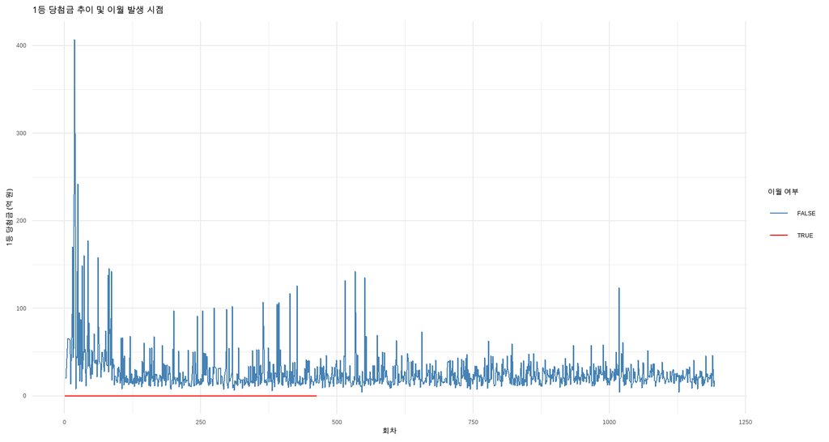

```r
# ✅ 코드 증거: 1등 당첨금 추이 시각화
lotto_result_final %>%
  mutate(이월 = ifelse(`1등_게임당당첨금_num` == 0, TRUE, FALSE)) %>%
  ggplot(aes(x = 회차, y = `1등_게임당당첨금_num` / 1e8, color = 이월)) +
  geom_line() +
  scale_color_manual(values = c("steelblue", "red")) +
  labs(title = "1등 당첨금 추이 및 이월 발생 시점",
       x = "회차", y = "1등 당첨금 (억 원)", color = "이월 여부") +
  theme_minimal()
```

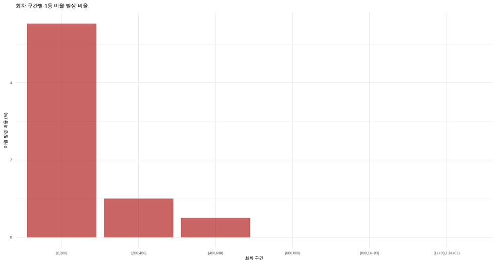

```r
# 회차 구간별 이월 발생 비율
lotto_result_final %>%
  mutate(이월 = ifelse(`1등_게임당당첨금_num` == 0, 1, 0),
         구간 = cut(회차, breaks = seq(0, 1200, 200), right = FALSE)) %>%
  group_by(구간) %>%
  summarise(이월비율 = mean(이월) * 100) %>%
  ggplot(aes(x = 구간, y = 이월비율)) +
  geom_col(fill = "firebrick", alpha = 0.7) +
  labs(title = "회차 구간별 1등 이월 발생 비율",
       x = "회차 구간", y = "이월 발생 비율 (%)") +
  theme_minimal()
```

`-` **극단적 변동성 존재**

- 초기(1~100회차) 구간에서 **이월이 연속적으로 발생**, 1등 당첨금이 **400억 원 이상 급등하는 구간 존재**
- 이후 300회차 이후부터는 이월 빈도가 줄며, **20~30억 원대 안정 구간으로 진입**

-> **제도 도입 초기의 불안정성과 참여자 확산의 과도기적 현상을 반영**

`-` **이월의 구조적 역할**

그래프상 **빨간 구간(이월 회차)**이 반복적으로 등장하며, 직후 **상금 급등 현상**이 나타남

이는 단순한 확률 이벤트가 아니라, **이월 -> 기대감 상승 -> 판매 증가 -> 상금 상승**으로 이어지는 **경제적/심리적 메커니즘**을 시사함

-> 이월은 로또 판매를 촉진하는 **내재적 구조 장치**로 작동함

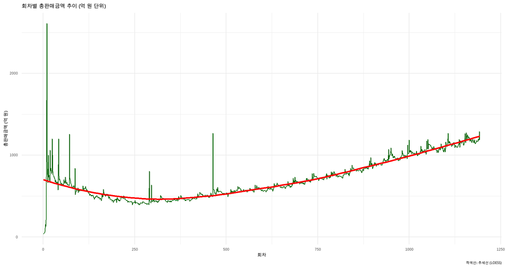

```r
lotto_result_final %>%
  ggplot(aes(x = 회차, y = 총판매금액 / 1e8)) +
  geom_line(color = "darkgreen") +
  geom_smooth(method = "loess", se = FALSE, color = "red", linewidth = 1) +
  labs(title = "회차별 총판매금액 추이 (억 원 단위)",
       x = "회차", y = "총판매금액 (억 원)",
       caption = "적색선: 추세선 (LOESS)") +
  theme_minimal()
```

`-` **판매금액 vs 당첨금의 비대칭 구조**

누적된 매출은 **소액당첨과 이월 상금으로 재분배되는 구조**임을 의미

-> 대다수의 소액당첨자 + 드문 대당첨자라는 **불균등한 분포 구조**가 지속됨

## 4. 누락과 왜곡

### (1) 이 데이터가 보여주지 않는 것은 무엇인가?

```r
# ✅ 코드 증거: 판매점 등수 구조 확인
round_shops_final %>%
  count(등수)
```

| 등수 | n |
| --- | --- |
| 1등 | 39155 |
| 2등 | 51163 |

- 이 데이터는 **‘결과 중심 구조’**만 보여줌
- 즉, 추첨번호/당첨금/판매점은 보이지만 **누가, 어떻게, 왜 구매했는가는 완전히 비가시적**임
- 모든 낙첨자는 데이터에서 사라지고, **성공(1,2등)만 기록된 사회적 서사**만 남음
- 데이터는 확률의 구조만 보여주고, **실패의 일상성은 삭제**되어 있음

### (2) 누락된 목소리(데이터에 반영되지 못한 집단/현상)는 무엇인가?

```r
# ✅ 코드 증거: place_master_final의 주요 열 확인
glimpse(place_master_final)
```

```
## Rows: 9,238
## Columns: 5
## $ 시도     <chr> "강원", "강원", "강원", "강원", "강원", "강원", "강원", "강원", "강원", "강원", "…
## $ 시군구   <chr> "강릉시", "강릉시", "강릉시", "강릉시", "강릉시", "강릉시", "강릉시", "강릉시", "강릉시"…
## $ 상호명   <chr> "오복복권", "유명복권대박", "홍익슈퍼", "꿈로또복권전문점", "아성로또복권", "일송로또", "천하명당…
## $ 전화번호 <chr> "033-648-0393", "033-642-2225", "033-651-7650", "033-645-4643…
## $ 주소     <chr> "강원 강릉시 율곡로 2807", "강원 강릉시 율곡로 2793", "강원 강릉시 가작로 311 1층", "강…
```

- 로또의 주체는 참여자이지만, 데이터는 그들의 **사회경제적 맥락을 포함하지 않음**
- 주요 변수(시도, 시군구, 상호명, 전화번호, 주소)는 **모두 판매점(공급자) 중심 변수**로만 구성되어 있으며, **구매자(수요자) 관련 변수는 전혀 존재하지 않음**
- 구매자의 연령/성별/소득/구매빈도 같은 정보가 없어, **“누가 복권을 사고 있는가?”**라는 사회적 질문은 이 데이터로 분석 불가
- 따라서 데이터는 구조적으로 **성공한 결과의 기록만 담고, 참여한 사람의 맥락은 배제하는 비대칭적 시각**을 가짐

### (3) 수집 과정에서 발생했을 수 있는 편향

```r
# ✅ 코드 증거: 1등/2등만 존재 확인
unique(round_shops_final$등수)
```

```
## [1] "1등" "2등"
```

`-` **공개 편향**

- 동행복권은 1/2등만 공개하고, 3등 이하 판매점은 비공개
- 이는 희망을 자극하는 정보만 남기고, 일상적 확률을 배제하는 **제도적 편향**임

```r
# ✅ 코드 증거: 시도별 판매점 수 분포
place_master_final %>%
  count(시도, sort = TRUE)
```

| 시도 | n |
| --- | --- |
| 경기 | 2315 |
| 서울 | 1655 |
| 경남 | 638 |
| 부산 | 623 |
| 인천 | 527 |
| 충남 | 496 |
| 경북 | 440 |
| 대구 | 436 |
| 전북 | 313 |
| 충북 | 311 |

[output cut: 7 more lines]

`-` **지역 편향**

- 판매점 수 자체가 지역마다 다르므로 서울/경기 지역은 당첨 확률이 높아 보이지만, 이는 실제 운의 집중이 아니라 **점포 수(노출량)**의 효과일 가능성이 높음
- 따라서 당첨이 몰린다는 해석은 실제 운의 편중이 아니라 **표본 크기 효과**일 가능성이 큼

```r
# ✅ 코드 증거: 각 데이터의 회차 범위 확인
range(lotto_result_final$회차)
```

```
## [1]    1 1193
```

```r
range(round_shops_final$회차)
```

```
## [1]  262 1193
```

`-` **시간적 편향**

- round_shops_final은 262회차 이후 데이터만 존재하며, **초기 1~261회차 정보는 완전히 누락**되었음
- 즉, 로또 제도 도입 초기의 **시장 구조 변화나 공개 방식 전환 시점은 데이터상으로 확인 불가능함**

## 5. 메타 질문

### (2) 이 데이터는 내 경험/관심/사회적 맥락과 어떤 연결이 있는가?

- 이 데이터는 통계학적 확률의 전형이지만, 사회적으로 보면 **희망의 구조적 불평등**을 보여줌
- 누구나 같은 확률로 사지만, 당첨의 경험은 압도적으로 집중됨
- 로또 데이터는 나에게 **“확률의 사회학적 얼굴”**을 보여준 사례였음
- 단순히 숫자를 보는 게 아니라, 그 숫자를 둘러싼 **인간의 감정**을 함께 읽게 만들었음

### (3) 지금 단계에서 “더 알고 싶다”는 충동이 생기는 부분은 어디인가?

- 당첨 판매점이 특정 지역(예: 서울, 경기)에 집중되는 이유가 단순한 인구 효과인지, 아니면 **사회경제적 요인**이 작용한 결과인지 더 알고 싶음
- 이월이 발생할 때 실제 판매량이 얼마나 급등하는지 -> 이월이 **심리적 기대를 자극해 매출을 끌어올리는 구조적 장치**가 맞는지 검증하고 싶음

# resonance

## 1.본능적 공명

### (1) 이 데이터를 처음 보았을 때 가장 먼저 떠오른 느낌은 무엇인가?

```r
# 총판매금액과 1등 1인당 상금(회차별) 추세 비교
ratio_df <- tibble(
  등위 = c("1등", "2등", "3등", "4등", "5등"),
  당첨자수 = c(
    sum(lotto_result_final$`1등_당첨게임수_num`, na.rm = TRUE),
    sum(lotto_result_final$`2등_당첨게임수_num`, na.rm = TRUE),
    sum(lotto_result_final$`3등_당첨게임수_num`, na.rm = TRUE),
    sum(lotto_result_final$`4등_당첨게임수_num`, na.rm = TRUE),
    sum(lotto_result_final$`5등_당첨게임수_num`, na.rm = TRUE)
  ),
  총상금 = c(
    sum(lotto_result_final$`1등_등위별총당첨금액_num`, na.rm = TRUE),
    sum(lotto_result_final$`2등_등위별총당첨금액_num`, na.rm = TRUE),
    sum(lotto_result_final$`3등_등위별총당첨금액_num`, na.rm = TRUE),
    sum(lotto_result_final$`4등_등위별총당첨금액_num`, na.rm = TRUE),
    sum(lotto_result_final$`5등_등위별총당첨금액_num`, na.rm = TRUE)
  )
) %>%
  mutate(
    상금비율 = 총상금 / sum(총상금),
    당첨자수비율 = 당첨자수 / sum(당첨자수)
  )
# ✅ 전체 합계 및 비율 계산
total_prize <- sum(ratio_df$총상금)
total_people <- sum(ratio_df$당첨자수)

ratio_df <- ratio_df %>%
  mutate(
    상금비율 = 총상금 / total_prize,
    당첨자수비율 = 당첨자수 / total_people
  )  %>%
  mutate(
    총상금 = format(총상금, big.mark = ",", scientific = FALSE),
    당첨자수 = format(당첨자수, big.mark = ",", scientific = FALSE),
    상금비율 = percent(as.numeric(상금비율), accuracy = 0.01),
    당첨자수비율 = percent(as.numeric(당첨자수비율), accuracy = 0.01)
  )

# ✅ 결과 출력
knitr::kable(ratio_df, caption = "등위별 당첨자수 및 상금 비율 (누적 기준)")
```

등위별 당첨자수 및 상금 비율 (누적 기준)

| 등위 | 당첨자수 | 총상금 | 상금비율 | 당첨자수비율 |
| --- | --- | --- | --- | --- |
| 1등 | 9,906 | 20,006,828,769,680 | 47.63% | 0.00% |
| 2등 | 59,983 | 3,333,609,066,147 | 7.94% | 0.00% |
| 3등 | 2,262,487 | 3,334,023,594,937 | 7.94% | 0.12% |
| 4등 | 110,772,994 | 5,918,318,986,172 | 14.09% | 5.74% |
| 5등 | 1,815,474,430 | 9,411,114,070,000 | 22.41% | 94.14% |

- 확률은 공평하지만, 결과는 불평등함
- 데이터가 보여주는 건 단순한 로또 통계가 아니라, **운의 계층 구조**였음
- 1등 당첨자는 전체의 극소수지만, **상금의 절반을 가져감**
- **운의 세계조차 불평등하다**는 충격적 사실이 드러남

```r
region_ratio <- round_shops_final %>%
  filter(등수 == "1등") %>%
  count(시도, name = "당첨점포수") %>%
  mutate(당첨비율 = 당첨점포수 / sum(당첨점포수))

# 비율이 높은 순으로 정렬
region_ratio_sorted <- region_ratio %>% arrange(desc(당첨비율))
region_ratio_sorted
```

| 시도 | 당첨점포수 | 당첨비율 |
| --- | --- | --- |
| 경기 | 10066 | 0.257080833 |
| 서울 | 7396 | 0.188890308 |
| 부산 | 2836 | 0.072430086 |
| 인천 | 2448 | 0.062520751 |
| 경남 | 2297 | 0.058664283 |
| 충남 | 1997 | 0.051002426 |
| 경북 | 1709 | 0.043647044 |
| 대구 | 1579 | 0.040326906 |
| 전남 | 1302 | 0.033252458 |
| 충북 | 1292 | 0.032997063 |

[output cut: 7 more lines]

### (2) 어떤 부분에서 놀람·의문·거부감이 생겼는가?

```r
region_ratio %>%
  filter(시도 %in% c("서울", "경기","인천")) %>%
  summarise(수도권_당첨비율 = sum(당첨비율))
```

| 수도권_당첨비율 |
| --- |
| 0.5084919 |

- 놀라운 부분은, **행운의 절반이 수도권에 집중되어 있다**는 사실이었음
- 로또는 확률적으로 전국이 동일해야 하지만, 실제로는 특정 지역에 편중되어 있었음
- **행운이 특정 공간에 집중된다는 사실 자체가 공정성의 환상을 흔들었음**

### (3) 내가 기대했던 것과 다르게 나온 부분은 무엇인가?

```r
region_ratio_sorted %>% tail(5)
```

| 시도 | 당첨점포수 | 당첨비율 |
| --- | --- | --- |
| 광주 | 1169 | 0.029855702 |
| 대전 | 1055 | 0.026944196 |
| 울산 | 936 | 0.023904993 |
| 제주 | 492 | 0.012565445 |
| 세종 | 166 | 0.004239561 |

- 전국이 비슷할 줄 알았지만 실제 결과는 예상보다 훨씬 **극단적이고 불균형적**이었음
- 세종/제주처럼 나름 인구와 소득이 있는 지역도 행운의 분포에서는 완전히 **소외된 영역**이었음
- 결국, 로또의 확률은 평등하지만 **결과는 공간적으로 불평등**했고, 상금도 소수에게 집중되는 패턴이 명확했음
- 즉, **운의 분포가 사회의 구조를 닮아 있음**

## 2. 학문적 공명

### (1) 이 데이터가 기존 지식(이론, 교재, 연구)과 연결되는 지점은 무엇인가?

- 이 데이터는 표면적으로는 복권 당첨 결과지만, 이면에는 불평등의 통계적 구조가 숨어 있음
- 즉, 모두에게 동일한 확률이 주어졌다는 **명제는 확률적 평등**에 해당하지만, **현실의 결과는 확률적 불평등**을 보여줌
- 이는 사회과학에서 말하는 **확률의 사회적 재현**(행운조차 사회 구조를 따라 분포한다)와 연결됨

### (2) 떠오르는 통계/수학/사회과학적 개념은 무엇인가?

`-` **지니계수(Gini Coefficient)**

- 소득이나 상금 분포의 불평등 정도를 0~1 사이 값으로 표현하는 지표
- **0은 완전 평등 (모두 동일 금액), 1은 완전 불평등 (한 명이 전부 독점)**
- 일반적으로 선진국 소득 분포는 0.3~0.4, 개발도상국은 0.4~0.6 수준임

`-` **로렌츠 곡선 (Lorenz Curve)**

- 소득, 상금, 자산 등의 누적 분포를 나타내는 곡선으로, 전체 구성원 중 얼마나 불평등하게 값이 분포되어 있는지를 보여줌
- **곡선이 45°선에서 멀수록, 지니값이 높을수록 집중/불평등 심화**

`-` **파레토 법칙(80:20 법칙)**

- 상금의 상위 약 20%의 당첨자가 전체 상금의 80% 이상을 차지한다는 법칙
- 이는 로또뿐 아니라 **소득, 자산, 판매량 분포 등 현실의 불평등 현상과 동일한 패턴**임

`-` **마태 효과 — 행운의 누적과 집중**

- **“있는 자는 더욱 받고, 없는 자는 더 빼앗긴다”** (성서 마태복음 25:29에서 유래한 사회학 개념)

### (3) 기존 연구 결과와 비교했을 때의 유사점·차이점

#### **유사점 : 운의 불평등은 경제 불평등을 닮았다**

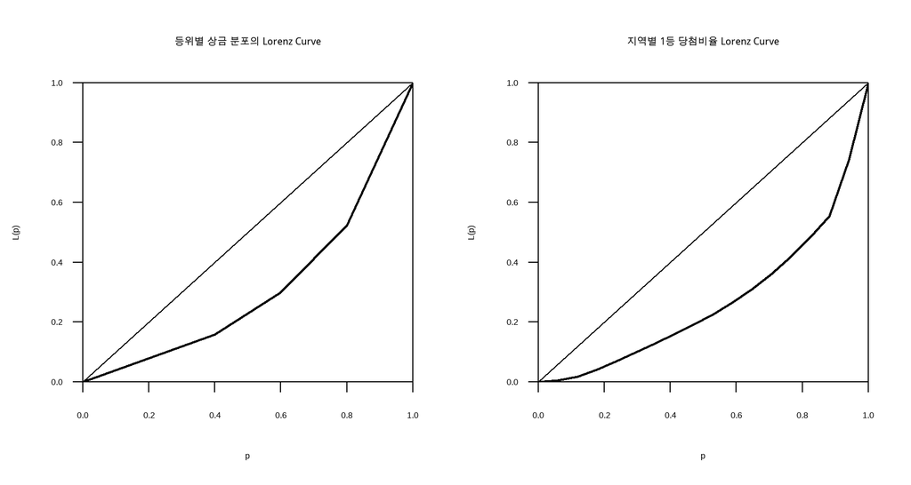

```r
par(mfrow=c(1,2))
# (a) 등위별 상금 분포
prize_share <- c(47.63, 7.94, 7.94, 14.09, 22.41)
Lc(prize_share) %>% plot(main="등위별 상금 분포의 Lorenz Curve")
gini_prize <- ineq(prize_share, type="Gini")

# (b) 지역별 1등 당첨 분포
reg_share <- region_ratio$당첨비율
plot(Lc(reg_share), main="지역별 1등 당첨비율 Lorenz Curve")
```

```r
gini_region <- ineq(reg_share, type="Gini")

gini_prize
```

```
## [1] 0.3753625
```

```r
gini_region
```

```
## [1] 0.4629234
```

```r
par(mfrow=c(1,1))
```

- **상금 분포 지니 = 약 0.38, 지역별 분포 지니 = 약 0.46 -> 중간 이상 불평등**
- 상금 분포와 소득 분포 모두, 초기 완만하다가 상위 구간에서 급격히 상승하는 **우상형 곡선**을 그림
- 로또 데이터에서는 **운의 분배가 소득의 분배보다 더 불평등하다**는 통계적 사실이 드러남

```r
# 누적 비율 계산
ratio_df %>%
  mutate(
    누적상금비율 = cumsum(as.numeric(str_replace(상금비율, "%", ""))) / 100
  ) %>%
  dplyr::select(등위, 상금비율, 누적상금비율)
```

| 등위 | 상금비율 | 누적상금비율 |
| --- | --- | --- |
| 1등 | 47.63% | 0.4763 |
| 2등 | 7.94% | 0.5557 |
| 3등 | 7.94% | 0.6351 |
| 4등 | 14.09% | 0.7760 |
| 5등 | 22.41% | 1.0001 |

#### **차이점 : 확률의 불평등은 선택 불가능한 구조이다**

`-` 로또 불평등의 근본 원인

- 소득 불평등은 노력/교육/정책 등으로 완화될 수 있지만, 로또의 불평등은 **확률적 시스템 내부에서 구조적으로 고정**되어 있음
- 아무리 많이 사도, 확률은 동일하게 낮음

`-` 참여 기회와 인지의 차이

- 로또는 공정한 확률을 표방하지만, 실제로는 판매점 접근성, 홍보, 유동인구 등 **사회적 자본의 집중**이 행운의 기회를 왜곡함
- 확률의 평등 ≠ 결과의 평등

`-` 사회학적 시사점

- Kahneman & Tversky(1979)의 Prospect Theory에 따르면, 인간은 낮은 확률의 사건에 과도하게 반응하고 ’공정한 기회’라는 인지적 착각 속에서 비합리적 선택을 반복함
- 로또 또한 이 심리적 메커니즘을 활용하는 제도적 구조로서, **공정성의 상징이면서 동시에 불평등의 재현**이라는 역설적 특성을 지닌다

## 3. 사회적 공명

### (1) 이 데이터는 사회·집단·문화적 맥락에서 어떤 의미를 가지는가?

```r
# 수도권 집중도(1등 배출점 기준)
region_ratio <- round_shops_final %>%
  dplyr::filter(등수 == "1등") %>%
  dplyr::count(시도, name = "당첨점포수") %>%
  dplyr::mutate(당첨비율 = 당첨점포수 / sum(당첨점포수))

region_ratio %>%
  filter(시도 %in% c("서울","경기","인천")) %>%
  summarise(수도권_당첨비율 = sum(당첨비율))
```

| 수도권_당첨비율 |
| --- |
| 0.5084919 |

- **수도권 집중** : 서울/경기/인천에서 1등 점포가 약 50.8% 발생
- 단순히 운의 결과가 아니라, **행운이 공간화되고 구조화되는 사회적 현상**을 보여줌

```r
repeat_winners <- round_shops_final %>%
  filter(등수=="1등") %>%
  count(상호명, sort = TRUE) %>%
  filter(n >= 2)
head(repeat_winners, 10)
```

| 상호명 | n |
| --- | --- |
| 행운복권방 | 510 |
| 복권나라 | 457 |
| 노다지복권방 | 378 |
| 복권명당 | 363 |
| 복권방 | 351 |
| 로또복권 | 322 |
| 천하명당복권방 | 283 |
| 로또복권방 | 282 |
| 돈벼락맞는곳 | 259 |
| 대박복권방 | 221 |

### (2) 특정 집단이나 계층에 더 큰 영향을 주는가?

```r
# 상위/하위 시도 비교
region_ratio %>% arrange(desc(당첨비율)) %>% head(5)
```

| 시도 | 당첨점포수 | 당첨비율 |
| --- | --- | --- |
| 경기 | 10066 | 0.25708083 |
| 서울 | 7396 | 0.18889031 |
| 부산 | 2836 | 0.07243009 |
| 인천 | 2448 | 0.06252075 |
| 경남 | 2297 | 0.05866428 |

`-` **상권 중심지 판매점의 구조적 유리함**

- 로또 판매는 기본적으로 **위치 사업**임
- **상권/유동인구가 집중된 곳**에 더 많은 판매점이 존재하며, 그만큼 당첨 노출 빈도도 높아짐

`-` **법적·제도적 시사점**

- 「복권 및 복권기금법」은 판매권 거래/위탁/가격조작 등에 대해 제재를 가하지만, **반복 당첨점포나 지역 편중 현상 자체를 막는 조항은 없음**
- 즉, 명당으로 인한 기회의 집중은 법적으로 제재되지 않으며, 구조적으로 공정성을 보완하는 제도적 장치는 미비함
- 이는 **‘합법적 편중 구조’**로서, 판매점의 위치·브랜딩이 운의 확률을 실질적으로 왜곡하는 상황을 낳음

### (3) 사회적 문제나 담론과 연결된다면 무엇인가?

`-` **“명당 상업화”— 행운의 자본화**

- 반복 당첨점이 명당으로 브랜딩되며, 상권 홍보/판매량 증가/점포 수익 확대 등 **행운의 경제적 독점**이 발생함
- 명당 신화는 공정한 확률이라는 로또의 본질과 충돌하며, **운의 사유화**라는 사회적 논란을 낳음

`-` **“희망의 역설” — 복권의 사회적 안전판인가, 도박인가**

- 경제 불황기마다 복권 매출은 오히려 증가함
- **2025년 1월 30일자 Korea JoongAng Daily 보도**에 따르면, **2024년 국내 복권 판매액은 약 5조 9,500억 원(≈ 5.95 조 원)**으로 사상 최고치를 기록했음
- 로또는 **경제적 불평등의 완충 장치**이자 **심리적 보상 메커니즘**으로 기능함

`-` **“공정성의 역설” — 확률은 평등하나 결과는 불평등함**

- 로또는 법적으로 모든 구매자에게 동일 확률을 부여하지만, 실제 결과는 **사회적 자본(정보, 접근성, 지역성)**에 따라 달라짐

## 4. 심리·문화적 공명

### (1) 개인적 경험(가족, 친구, 나의 삶)과 어떤 연결이 있는가?

```r
# ✅ 연도별 집계
lotto_yearly <- lotto_result_final %>%
  mutate(연도 = year(추첨일)) %>%
  group_by(연도) %>%
  summarise(연도별_총판매금액 = sum(총판매금액, na.rm = TRUE) / 1e8)

# ✅ 시각화
ggplot(lotto_yearly, aes(x = 연도, y = 연도별_총판매금액)) +
  geom_line(color = "#264653", linewidth = 1) +
  geom_point(color = "#e76f51", size = 3) +
  geom_smooth(se = FALSE, color = "#e76f51", linetype = "dashed") +
  geom_vline(xintercept = c(2020, 2024), color = "red", linetype = "dotted") +
  annotate("text", x = 2020.3, y = max(lotto_yearly$연도별_총판매금액)*0.9,
           label = "COVID 경기침체기", color = "red", size = 3, hjust = 0) +
  labs(
    title = "📉 연도별 로또 총판매금액 추이 (억 원 단위)",
    x = "연도", y = "총판매금액(억 원)"
  ) +
  theme_minimal(base_family = "nanumgothic") +
  theme(plot.title = element_text(face = "bold", size = 15))
```

[output not shown]

- “이번 주엔 한 번 사볼까?” 하는 말은 단순한 농담 같지만, **불확실한 시대의 감정적 언어**가 될 수 있음
- 경기 침체와 불안이 클수록 복권 구매가 증가한다는 것은, 이 데이터가 **경제심리학적 지표로도 기능**함
- 한 장의 복권은 단순한 소비가 아니라, **삶의 불안정성에 대한 감정적 응답**임

### (2) 대중문화·미디어·통념과 어떤 접점을 가지는가?

`-` **영화 -〈육사오(6/45, 2022)〉**

- 남한 병사가 당첨 복권을 잃어버리고, 그것이 군사분계선을 넘어 북한 병사 손에 들어가며 사건이 일어나는 내용
- **운이 국가/이념의 경계를 넘어 통용되는 상징적 장치**로 등장함

`-` **영화 - 〈Lottery Ticket, 2010〉**

- 흑인 커뮤니티 내에서 주인공이 3억 달러 복권에 당첨된 후, 주변의 욕망/폭력/불평등에 휘말리는 이야기
- 복권이 **사회적 불평등의 거울이자 욕망의 시험대**로 그려짐

`-` **TV프로그램 - 〈로또싱어〉(2020)** - 노래 한 곡으로 인생이 바뀔 수 있다는 콘셉트의 경연 프로그램

- 로또는 여기서 **‘한 방의 역전’**이라는 문화적 은유로 쓰임

### (3) 이 데이터가 나의 감정·가치관과 어떻게 부딪히는가?

```r
# 등위별 누적 상금비율 계산
ratio_df %>%
  mutate(누적상금비율 = cumsum(as.numeric(str_replace(상금비율, "%", ""))) / 100) %>%
  dplyr::select(등위, 상금비율, 누적상금비율)
```

| 등위 | 상금비율 | 누적상금비율 |
| --- | --- | --- |
| 1등 | 47.63% | 0.4763 |
| 2등 | 7.94% | 0.5557 |
| 3등 | 7.94% | 0.6351 |
| 4등 | 14.09% | 0.7760 |
| 5등 | 22.41% | 1.0001 |

- 1,2등이 전체 상금의 절반 이상을 차지 -> **희소한 행운이 과도하게 집중된 구조**
- 그러나 사람들은 그 사실을 알고도 계속 구매함. **확률이 아니라 희망을 사는 것**으로 볼 수 있음
- 희망은 통계의 언어가 아니라 감정의 언어이고, 로또는 그 언어의 가장 생생한 형태가 될 수 있음

## 5. 집단적 공명

### (1) 이 데이터를 함께 본 다른 사람들은 어떤 반응을 할 것 같은가?

- 일부는 **로또는 결국 확률이 공정하다**며 통계적 평등을 강조할 것이고, 또 다른 일부는 **결과가 불평등하다면 그건 구조적 문제**라며 사회적 요인을 지적할 것임
- 특히 수도권 집중(약 50.8%)과 반복 당첨점(명당)의 존재는 행운마저 불평등하다는 해석과 그건 단순히 판매점 밀집도의 결과라는 해석이 맞부딪히는 지점이 됨
- 이 데이터는 **공정성에 대한 각자의 정의가 다름을 드러내는 거울**이 됨

### (2) 조별 토론에서 이 데이터가 어떤 논쟁을 불러올 수 있는가?

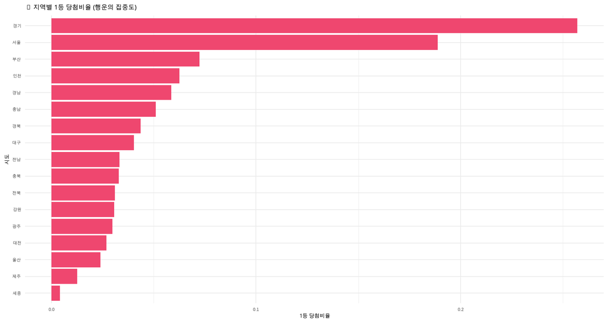

```r
# 수도권 집중도와 1등 점포수 비교 (논쟁 근거 시각화)
region_ratio %>%
  arrange(desc(당첨비율)) %>%
  ggplot(aes(x = reorder(시도, 당첨비율), y = 당첨비율)) +
  geom_col(fill = "#ef476f") +
  coord_flip() +
  labs(title = "🎯 지역별 1등 당첨비율 (행운의 집중도)",
       x = "시도", y = "1등 당첨비율") +
  theme_minimal()
```

`-` **운의 불평등 vs 기회의 평등**

- 한쪽은 모두 같은 확률을 가진다고 말하고,다른 쪽은 현실적으로 명당 / 접근성 / 정보의 차이가 작동한다고 반박할 수 있음

`-` **복권의 사회적 기능**

- 일부는 복권은 서민의 꿈을 지탱하는 희망의 통로라고 말할 것이고, 다른 일부는 불평등을 유지시키는 심리적 안전판이라 비판할 것임
- **해석은 사회적 위치와 세계관에 따라 달라질 수 있음**

### (3) 공명 경험을 공유했을 때, 나의 생각은 어떻게 달라질 수 있는가?

- 처음엔 단순히 복권의 불평등이라 생각했지만, 다른 의견을 들으며 **공정성의 정의가 사람마다 다르다**는 걸 깨닫게 됨
- 누군가 로또는 공정하기 때문에 오히려 위로가 된다고 말했을 때, 나는 공정한 절차와 공정한 결과가 다를 수 있음을 인정하게 됨
- **이 데이터는 논쟁을 통해 성장하는 공명을 일으킴**

## 6. 메타질문

### (1) 이 데이터가 나에게 “다시 보고 싶다”는 충동을 일으킨 지점은 어디인가?

- 로또의 불평등이 단순히 확률적 현상이 아니라 **사회적 구조와 연결된다**는 사실을 발견했을 때, 단순히 숫자를 넘어서 **사람과 공간의 패턴**을 더 보고 싶다는 충동이 생겼음
- 특히 수도권 집중과 반복 당첨점 데이터를 보며, 명당이란 신화가 실제로 **어떤 사회경제적 요인(유동인구, 상권 규모 등) 과 결합하는지** 구체적으로 분석해보고 싶다는 생각이 들었음

### (2) 공명을 기록하면서, 나의 관심이 어디로 이동했는가?

- 처음에는 **운의 불평등 그 자체에 주목**했지만, 점차 사람들의 **행운에 대한 믿음/기대/집단 심리로 관심이 이동**했음
- 데이터는 숫자를 보여줬지만, 그 숫자를 믿는 사람들의 **이야기**가 궁금해졌음
- 즉, 통계적 분석에서 **심리적/문화적 해석으로 관심의 중심이 이동**했음

### (3) 지금 이 순간 떠오르는 가장 큰 질문은 무엇인가?

- “우리는 왜 희박한 확률에 끌리는가?”
- **확률이 낮을수록 오히려 더 강한 기대를 품는 인간의 역설적 심리** -> 이것이 데이터가 던진 마지막 질문었음
- 공정성의 착각, 희망의 필요, 그리고 불평등의 정당화까지. 로또는 단순한 복권이 아니라 **현대 사회의 축소판**이라고 볼 수 있음
- 그러면 **로또를 사는 행위는 통계적 오류인가, 아니면 인간다운 선택인가**라는 의문이 듦

# Insight

## 1. 패턴발견

### (1) 데이터에서 반복적으로 나타나는 규칙·패턴은 무엇인가?

```r
# ✅ 결과 출력
knitr::kable(ratio_df, caption = "등위별 당첨자수 및 상금 비율 (누적 기준)")
```

등위별 당첨자수 및 상금 비율 (누적 기준)

| 등위 | 당첨자수 | 총상금 | 상금비율 | 당첨자수비율 |
| --- | --- | --- | --- | --- |
| 1등 | 9,906 | 20,006,828,769,680 | 47.63% | 0.00% |
| 2등 | 59,983 | 3,333,609,066,147 | 7.94% | 0.00% |
| 3등 | 2,262,487 | 3,334,023,594,937 | 7.94% | 0.12% |
| 4등 | 110,772,994 | 5,918,318,986,172 | 14.09% | 5.74% |
| 5등 | 1,815,474,430 | 9,411,114,070,000 | 22.41% | 94.14% |

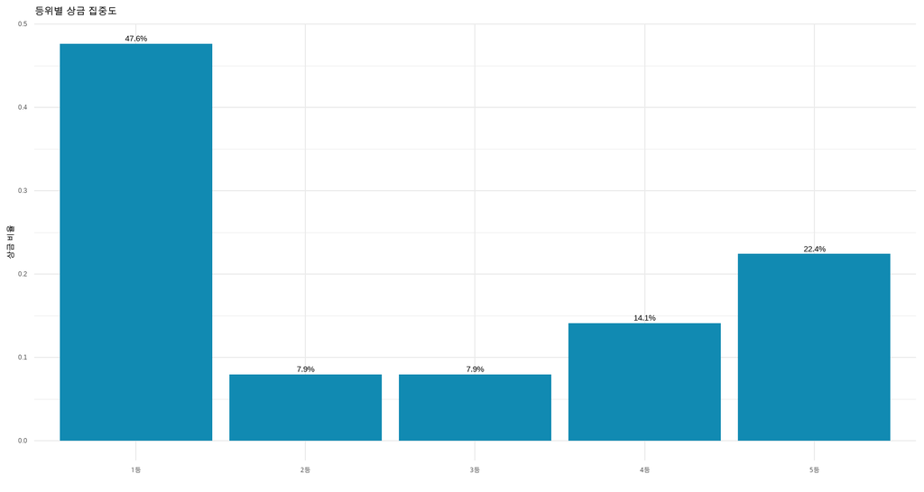

```r
# 등위별 상금 집중도
ratio_df_num <- lotto_result_final %>%
  summarise(
    `1등` = sum(`1등_등위별총당첨금액_num`, na.rm = TRUE),
    `2등` = sum(`2등_등위별총당첨금액_num`, na.rm = TRUE),
    `3등` = sum(`3등_등위별총당첨금액_num`, na.rm = TRUE),
    `4등` = sum(`4등_등위별총당첨금액_num`, na.rm = TRUE),
    `5등` = sum(`5등_등위별총당첨금액_num`, na.rm = TRUE)
  ) %>%
  pivot_longer(everything(), names_to = "등위", values_to = "총상금") %>%
  mutate(비율 = 총상금 / sum(총상금))

ggplot(ratio_df_num, aes(x = 등위, y = 비율)) +
  geom_col(fill = "#118ab2") +
  geom_text(aes(label = scales::percent(비율, accuracy = 0.1)), vjust = -0.5) +
  labs(title = "등위별 상금 집중도", y = "상금 비율", x = "") +
  theme_minimal()
```

- 상금의 **약 55%가 1~2등에 집중**되어 있음

### (2) 시간에 따른 변화나 주기성이 있는가?

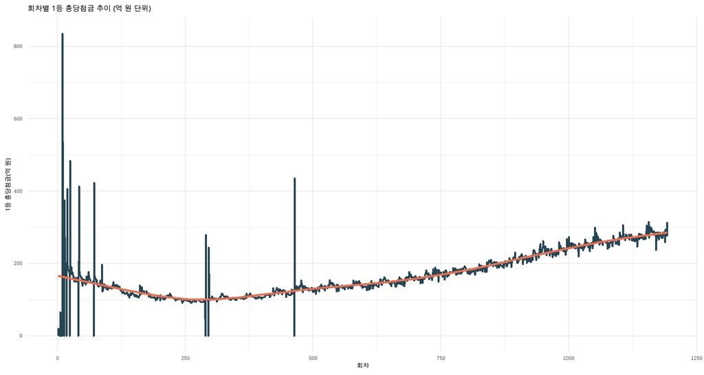

```r
# 회차별 1등 총당첨금 추이
lotto_result_final %>%
  ggplot(aes(x = 회차, y = `1등_등위별총당첨금액_num` / 1e8)) +
  geom_line(color = "#264653", linewidth = 0.8) +
  geom_smooth(se = FALSE, color = "#e76f51", linewidth = 1) +
  labs(title = "회차별 1등 총당첨금 추이 (억 원 단위)",
       x = "회차", y = "1등 총당첨금(억 원)") +
  theme_minimal()
```

```r
# ✅ 연도별 집계
lotto_yearly <- lotto_result_final %>%
  mutate(연도 = year(추첨일)) %>%
  group_by(연도) %>%
  summarise(연도별_총판매금액 = sum(총판매금액, na.rm = TRUE) / 1e8)

# ✅ 시각화
ggplot(lotto_yearly, aes(x = 연도, y = 연도별_총판매금액)) +
  geom_line(color = "#264653", linewidth = 1) +
  geom_point(color = "#e76f51", size = 3) +
  geom_smooth(se = FALSE, color = "#e76f51", linetype = "dashed") +
  geom_vline(xintercept = c(2020, 2024), color = "red", linetype = "dotted") +
  annotate("text", x = 2020.3, y = max(lotto_yearly$연도별_총판매금액)*0.9,
           label = "COVID 경기침체기", color = "red", size = 3, hjust = 0) +
  labs(
    title = "📉 연도별 로또 총판매금액 추이 (억 원 단위)",
    x = "연도", y = "총판매금액(억 원)"
  ) +
  theme_minimal(base_family = "nanumgothic") +
  theme(plot.title = element_text(face = "bold", size = 15))
```

[output not shown]

- 경기 침체기(예: 2020~2021년, 2024년)에는 상금과 총판매금액 모두 상승
- **경제 불확실성 속에서도 꾸준히 유지/상승되는 복권 수요**

### (3) 집단/범주 간 차이는 무엇인가?

```r
region_ratio_sorted
```

| 시도 | 당첨점포수 | 당첨비율 |
| --- | --- | --- |
| 경기 | 10066 | 0.257080833 |
| 서울 | 7396 | 0.188890308 |
| 부산 | 2836 | 0.072430086 |
| 인천 | 2448 | 0.062520751 |
| 경남 | 2297 | 0.058664283 |
| 충남 | 1997 | 0.051002426 |
| 경북 | 1709 | 0.043647044 |
| 대구 | 1579 | 0.040326906 |
| 전남 | 1302 | 0.033252458 |
| 충북 | 1292 | 0.032997063 |

[output cut: 7 more lines]

```r
region_ratio %>%
  filter(시도 %in% c("서울", "경기","인천")) %>%
  summarise(수도권_당첨비율 = sum(당첨비율))
```

| 수도권_당첨비율 |
| --- |
| 0.5084919 |

- 수도권(서울/경기/인천)에 전체 1등의 약 50.8%가 집중 -> **행운의 공간화가 뚜렷함**
- 행운이 무작위가 아니라 **사회적 자본의 공간 구조**를 따라 분포

## 2. 지식연결

### (1) 이 패턴은 내가 아는 지식·이론과 어떻게 연결되는가?

```r
library(ineq)
prize_share <- c(47.63, 7.94, 7.94, 14.09, 22.41) # 1등~5등 상금비율
gini_prize <- ineq(prize_share, type = "Gini")
gini_prize
```

```
## [1] 0.3753625
```

`-` **지니계수**

- 불평등의 대표적 지표로, 로또 상금 분포의 집중도를 정량적으로 표현함
- 지니계수 결과 약 0.38, 이는 OECD 국가 평균 소득 지니계수(약 0.33)보다 높아**“소득보다 운의 분배가 더 불평등하다”**는 점을 보여줌

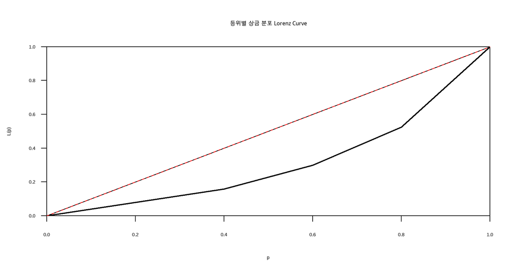

```r
Lc(prize_share) %>% plot(main = "등위별 상금 분포 Lorenz Curve")
abline(0, 1, col = "red", lty = 2)
```

`-` **로렌츠 곡선**

- 분포의 누적 불평등을 시각화할 수 있으며, 곡선이 45° 평등선에서 멀어질수록 집중이 심화됨

`-` **파레토 법칙**

- 부와 성과 및 행운이 모두 상위층에 집중

### (2) 기존 학문적 틀로 설명 가능한가, 새로운 틀이 필요한가?

- 로또 시스템은 모든 조합이 동일한 확률을 가진다는 **확률적 평등을 전제**함
- 그러나 실제 데이터에서는 결과의 불평등성과 수도권 편중이 통계적으로 확인됨
- 이는 확률이론만으로 설명할 수 없는 **사회적 요인(판매점 입지, 인구밀도, 경제력 등) 의 영향**을 시사함
- 따라서 단순한 균등분포 가정만으로는 현실을 설명하기 어렵고, **행동경제학(인간의 기대/심리 요인 등)과 공간통계학(지역적 군집 효과)을 결합한 분석이 필요함**

```r
# 📍 시도별 대표 위도/경도 (예시 좌표)
coords_df <- tibble(
  시도 = c("서울","부산","대구","인천","광주","대전","울산",
         "경기","강원","충북","충남","전북","전남","경북","경남","제주","세종"),
  위도 = c(37.55, 35.18, 35.87, 37.46, 35.16, 36.35, 35.54,
         37.28, 37.88, 36.64, 36.66, 35.82, 34.81, 36.57, 35.24, 33.50, 36.48),
  경도 = c(126.99, 129.07, 128.60, 126.70, 126.85, 127.38, 129.31,
         127.00, 128.35, 127.49, 126.80, 127.15, 126.46, 128.73, 128.67, 126.53, 127.29)
)

# 📊 기존 region_ratio에 좌표 결합
region_spatial <- region_ratio %>%
  left_join(coords_df, by = "시도")

# Moran’s I 계산을 위한 좌표 행렬
coords <- as.matrix(region_spatial[, c("경도", "위도")])

# 3-최근접 이웃 (k=3) 기준
nb <- knn2nb(knearneigh(coords, k = 3))
lw <- nb2listw(nb, style = "W")

# Moran’s I 계산
moran_result <- moran.test(region_spatial$당첨비율, lw)
moran_result
```

```
##
##  Moran I test under randomisation
##
## data:  region_spatial$당첨비율
## weights: lw
##
## Moran I statistic standard deviate = 2.8886, p-value = 0.001935
## alternative hypothesis: greater
## sample estimates:
## Moran I statistic       Expectation          Variance
##        0.31751149       -0.06250000        0.01730674
```

`-` **Moran’s I(공간자기상관)**

`-` **전망이론(행동경제학)**

- 사람은 확률을 객관적으로 보지 않고, **작은 확률을 과대평가, 큰 확률을 과소평가함**
- 혹시 나일지도 모른다는 기대감으로 구매 지속

`-` **도박자 오류(행동경제학)**

- **이전 결과가 다음 확률에 영향을 준다고 잘못 믿음**
- 이번엔 나올 때가 됐다, 이 번호는 안 나왔으니 이번엔 될 거야 같은 패턴형 믿음

### (3) 다른 데이터와 결합했을 때 어떤 확장이 가능한가?

- **통계청 지역별 소득소비 데이터** -> 상금 집중 지역과 소득수준의 상관관계 회귀분석
- **네이버 데이터랩 로또, 명당 검색량 구매 관심도** -> 실제 판매액 간 시계열 상관분석
- **실업률/소비심리지수/경기지표** -> 경기 침체기 복권 구매 증가 여부, 그래인저 인과검정 분석
- **SNS 텍스트 데이터** -> 긍정/부정 비율으로 희망 vs 체념 심리 정량화

## 3. 새로운 해석

### (1) 기존과 다른 해석 가능성은 무엇인가?

```r
library(readxl)
library(dplyr)
library(stringr)
library(tibble)
library(ggplot2)

# 1. 엑셀 파일 불러오기
pop_raw <- read_excel("행정구역_읍면동_별_5세별_주민등록인구_2011년__20251030164801.xlsx", skip = 1)

# 2. '계'로 시작하는 가장 마지막 열(가장 최근 연도)
latest_total_col <- grep("^계", names(pop_raw), value = TRUE) %>% tail(1)

# 3. 시도별 총인구 요약
population_df <- pop_raw %>%
  dplyr::select(시도 = 1, 인구수 = all_of(latest_total_col)) %>%
  group_by(시도) %>%
  summarise(인구수 = sum(as.numeric(인구수), na.rm = TRUE)) %>%
  filter(!str_detect(시도, "계|전국|남자|여자")) %>%
  mutate(시도 = str_remove_all(시도, "\\s"),
         인구수 = round(인구수))

# 🔹 4. 지역별 인구 대비 1등 점포 비율 계산
region_access <- region_ratio %>%
  mutate(시도 = case_when(
    시도 == "서울" ~ "서울특별시",
    시도 == "부산" ~ "부산광역시",
      시도 == "대구" ~ "대구광역시",
    시도 == "인천" ~ "인천광역시",
    시도 == "광주" ~ "광주광역시",
    시도 == "대전" ~ "대전광역시",
    시도 == "울산" ~ "울산광역시",
    시도 == "세종" ~ "세종특별자치시",
    시도 == "경기" ~ "경기도",
    시도 == "강원" ~ "강원특별자치도",
    시도 == "충북" ~ "충청북도",
    시도 == "충남" ~ "충청남도",
    시도 == "전북" ~ "전북특별자치도",
    시도 == "전남" ~ "전라남도",
    시도 == "경북" ~ "경상북도",
    시도 == "경남" ~ "경상남도",
    시도 == "제주" ~ "제주특별자치도",
    TRUE ~ 시도
  )) %>%
  left_join(population_df, by = "시도") %>%
  mutate(판매점_인구비 = 당첨점포수 / 인구수 * 1e6) %>%
  arrange(desc(판매점_인구비))

# 표 출력
knitr::kable(region_access[, c("시도", "당첨점포수", "인구수", "판매점_인구비")],
             caption = "시도별 인구 100만 명당 1등 당첨점포 수")
```

시도별 인구 100만 명당 1등 당첨점포 수

| 시도 | 당첨점포수 | 인구수 | 판매점_인구비 |
| --- | --- | --- | --- |
| 충청남도 | 1997 | 2136551 | 934.6840 |
| 부산광역시 | 2836 | 3248359 | 873.0562 |
| 울산광역시 | 936 | 1092634 | 856.6455 |
| 광주광역시 | 1169 | 1397122 | 836.7201 |
| 충청북도 | 1292 | 1592431 | 811.3381 |
| 인천광역시 | 2448 | 3046754 | 803.4781 |
| 강원특별자치도 | 1202 | 1509396 | 796.3450 |
| 서울특별시 | 7396 | 9318500 | 793.6900 |
| 제주특별자치도 | 492 | 665610 | 739.1716 |
| 경기도 | 10066 | 13721178 | 733.6105 |
| 전라남도 | 1302 | 1779599 | 731.6255 |
| 대전광역시 | 1055 | 1442228 | 731.5071 |
| 경상남도 | 2297 | 3210425 | 715.4816 |
| 전북특별자치도 | 1213 | 1727716 | 702.0830 |
| 경상북도 | 1709 | 2512441 | 680.2150 |
| 대구광역시 | 1579 | 2356372 | 670.0979 |
| 세종특별자치시 | 166 | 392230 | 423.2211 |

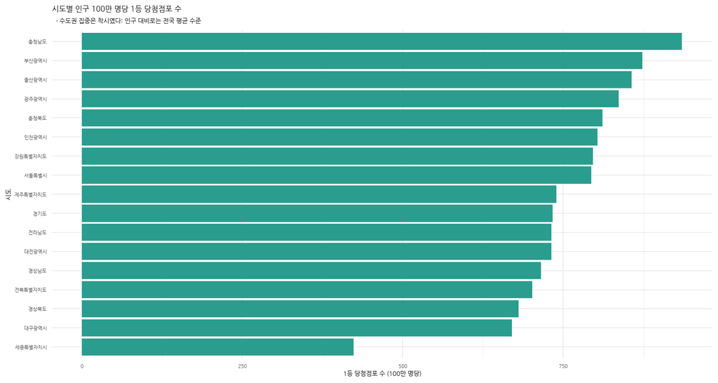

```r
# 시각화
ggplot(region_access, aes(x = reorder(시도, 판매점_인구비), y = 판매점_인구비)) +
  geom_col(fill = "#2a9d8f") +
  coord_flip() +
  labs(
    title = "시도별 인구 100만 명당 1등 당첨점포 수",
    subtitle = "→ 수도권 집중은 착시였다: 인구 대비로는 전국 평균 수준",
    x = "시도", y = "1등 당첨점포 수 (100만 명당)"
  ) +
  theme_minimal(base_family = "nanumgothic")
```

### (2) 데이터가 의도와 달리 드러낸 의미는 무엇인가?

- 이 분석은 수도권 집중을 입증하려는 의도였으나, 오히려 데이터는 그 신화를 스스로 반박했음
- 수도권은 운이 많은 곳이 아니라, 단지 사람이 많은 곳이었음
- 결국 문제는 **운의 불평등이 아니라, 기회의 접근성 불평등**임
- 복권 시스템은 모든 조합이 동일 확률로 공정하지만, **판매망/입지/인구 구조가 기회의 실제 접근성을 왜곡시킴**
- 즉, **확률의 평등이 결과의 평등으로 이어지지 않는것**이 로또의 사회적인 역설이 됨

### (3) 또 다른 이야기(Storytelling)로 표현한다면?

- 이제 명당을 찾아 헤매는 사람들의 이야기는 **운의 인프라를 설계하는 사회의 이야기로 바뀜**
- **과거의 서사: “서울엔 명당이 많다.”**
- **데이터의 서사: “서울엔 사람만 많다.”**
- **새로운 서사: “운의 밀도는 인구가 아니라 구조가 만든다.”**
- 즉, 행운은 무작위로 주어지는 것이 아니라 기회가 설계된 사회 구조 속에서 분배되는 자원임
- 공정한 로또란 단순한 확률의 공정성이 아니라, **접근성의 공정성**을 함께 설계하는 사회적 시스템이 됨

## 4. 역설·예외 발견

### (1) 기대와 어긋나는 부분은 무엇인가?

```r
# ✅ 연도별 집계
lotto_yearly <- lotto_result_final %>%
  mutate(연도 = year(추첨일)) %>%
  group_by(연도) %>%
  summarise(연도별_총판매금액 = sum(총판매금액, na.rm = TRUE) / 1e8)

# ✅ 시각화
ggplot(lotto_yearly, aes(x = 연도, y = 연도별_총판매금액)) +
  geom_line(color = "#264653", linewidth = 1) +
  geom_point(color = "#e76f51", size = 3) +
  geom_smooth(se = FALSE, color = "#e76f51", linetype = "dashed") +
  geom_vline(xintercept = c(2020, 2024), color = "red", linetype = "dotted") +
  annotate("text", x = 2020.3, y = max(lotto_yearly$연도별_총판매금액)*0.9,
           label = "COVID 경기침체기", color = "red", size = 3, hjust = 0) +
  labs(
    title = "📉 연도별 로또 총판매금액 추이 (억 원 단위)",
    x = "연도", y = "총판매금액(억 원)"
  ) +
  theme_minimal(base_family = "nanumgothic") +
  theme(plot.title = element_text(face = "bold", size = 15))
```

[output not shown]

- 인구 보정 결과, 수도권 집중 현상은 단순한 착시로 드러났고 운의 접근성은 전국적으로 비교적 균등하게 분포하고 있었음
- 따라서 공간적 요인만으로는 행운의 불평등을 설명하기 어렵다는 결론이 가능했음
- 그러나 **시간의 축으로 시야를 확장하면 새로운 모순이 등장**함
- 경기 침체기(예: 2020~2021년 코로나, 2024년 고금리기)에도 오히려 **로또 판매금액이 증가**하는 역행적 패턴이 나타남
- 경제가 나빠질수록 소비는 줄어들어야 하지만, 현실에서는 반대로 **희망 소비가 확대**되었음
- 이는 경제이론의 예측과 명백히 어긋나는 결과이며, **불황기에 복권이 더 잘 팔린다**는 사회적 역설을 보여줌

### (2) 예외적 사례가 보여주는 것은 무엇인가?

- 이 예외적 패턴은 복권이 단순한 오락재가 아니라, **심리적 보험**으로 작동한다는 점을 보여줌
- 경제적 불안이 커질수록 사람들은 **현실의 통제력 상실을 확률적 희망으로 보상**하려 함
- 즉, 복권은 불황기에 더욱 강화되는 **‘희망의 소비재’**가 됨
- **New York Times(2023)은 “People buy lottery tickets when the world feels unpredictable.”에서 불확실성이 커질수록 복권은 통제감의 대체재로 소비**된다고 분석했음

### (3) 이 역설/예외가 전체 이해를 어떻게 확장하는가?

- 앞선 분석이 행운의 불평등은 구조적이다라는 공간적 통찰을 제시했다면, 이번 역설은 그 위에 **희망의 소비는 심리적이다**라는 층위를 더함
- 복권은 공정하지 않지만, **공정하지 않기 때문에 더 많이 팔림**
- 이는 로또가 단순히 확률의 문제가 아니라, **사회가 불평등할수록 희망을 소비하는 구조로 진화한다**는 사실을 드러냄
- 불평등이 커질수록 사람들은 불공정한 게임에서조차 공정한 희망을 찾음
- 복권은 그래서 단순한 오락이 아니라, **희망의 유통 구조**이며, 불안한 사회일수록 더 강력하게 작동하는 **심리적 사회지표**가됨

## 5. 메타 반성

### (1) 이 통찰은 나만의 발견인가, 이미 알려진 사실의 확인인가?

[figure not shown]

```r
# ✅ Selenium 초기 연결
#rD <- rsDriver(remoteServerAddr = "localhost",
#                   browser = "chrome",
#                   geckover = NULL,
#                   iedrver = NULL,
#                   chromever = NULL,
#                   phantomver = NULL,
#                   port = 4600L)
#remDr <- rD$client
#remDr$open()


# ✅ 통계청 페이지로 이동
#remDr$navigate("https://www.index.go.kr/unify/idx-info.do?idxCd=4201&utm_source=chatgpt.com")
#Sys.sleep(5)   # 로딩 대기

# ✅ Ajax 요청 실행
#json_text <- remDr$executeScript("
#  return $.ajax({
#    url: '/unity/index/IndexTblGraphAjax.do',
#    type: 'GET',
#    data: {
#      sttsCd: '420101',   // 📈 경제성장률 코드
#      chartOrd: '1',
#      freq: 'Y',
#      startPrdDe: '1954',
#      endPrdDe: '2024'
#    },
#    async: false
#  }).responseText;
#")[[1]]

# ✅ JSON 파싱
#growth_df <- fromJSON(json_text)$resultList %>%
#  as.data.frame() %>%
#  dplyr::select(descDt, valNm, nmbrVal) %>%
#  rename(연도 = descDt, 항목 = valNm, 값 = nmbrVal) %>%
#  mutate(연도 = as.integer(연도), 값 = as.numeric(값))

#print(growth_df)

# ✅ 파일 저장 경로 설정 (원하는 경로로 수정 가능)
#save_path <- "C:/R study/economic_growth_1990_2024.csv"

# ✅ CSV로 저장
#write.csv(growth_df, save_path, row.names = FALSE, fileEncoding = "UTF-8")



growth_path <- "C:/R study/economic_growth_1990_2024.csv"

# ✅ CSV 불러오기
growth_df <- read.csv(growth_path, fileEncoding = "UTF-8")

# ✅ 연도 기준 데이터 결합
lotto_gdp <- lotto_yearly %>%
  left_join(growth_df %>% dplyr::select(연도, 값), by = "연도") %>%
  rename(GDP성장률 = 값) %>%
  filter(연도 >= 2010)

# ✅ 막대 + 로또 추세선 + GDP 성장률선
ggplot(lotto_gdp, aes(x = 연도)) +
  # ▩ 로또 판매금액 막대 (기본)
  geom_col(aes(y = 연도별_총판매금액 / 1e4),
           fill = "#2a9d8f", alpha = 0.4) +
  # ▩ 로또 판매금액 추세선 (막대 위)
  geom_line(aes(y = 연도별_총판매금액 / 1e4, color = "로또 판매금액(조 원)"),
            linewidth = 1.2) +
  geom_point(aes(y = 연도별_총판매금액 / 1e4, color = "로또 판매금액(조 원)"),
             size = 2) +
  # ▩ GDP 성장률선 (이중축)
  geom_line(aes(y = GDP성장률 * 2, color = "GDP 성장률(%)"),
            linewidth = 1.2, linetype = "solid") +
  geom_point(aes(y = GDP성장률 * 2, color = "GDP 성장률(%)"),
             size = 2) +
  scale_y_continuous(
    name = "GDP 성장률(%)",
    sec.axis = sec_axis(~./2, name = "로또 총판매금액 (조 원)")
  ) +
  scale_color_manual(
    name = "",
    values = c("GDP 성장률(%)" = "#e76f51",
               "로또 판매금액(조 원)" = "#1b9aaa")
  ) +
  labs(
    title = "📈 GDP 성장률과 로또 판매금액의 역행적 관계 (2010~2024)",
    subtitle = "→ 경기침체기(2020, 2024)에도 로또 판매는 오히려 증가",
    x = "연도"
  ) +
  theme_minimal(base_family = "nanumgothic") +
  theme(
    legend.position = "top",
    axis.title.y.left = element_text(color = "#e76f51", size = 12, face = "bold"),
    axis.title.y.right = element_text(color = "#2a9d8f", size = 12, face = "bold"),
    plot.title = element_text(face = "bold", size = 15)
  )
```

- 통계청 통합지표(2025)에 따르면, 한국의 실질 GDP 성장률은 **1990년대 9~10%의 고성장기에서 2010년대 이후 2~3%대 저성장 국면으로 전환되었고, 2020년에는 –0.7%로 급락한 뒤 2021년 일시 반등(4.6%) 후 다시 둔화함**
- 그런데 같은 시기 **로또 판매금액은 오히려 지속적으로 상승했음**
- 즉, **경제 성장률과 복권 매출 간의 반비례적 관계가 드러남**
- 이는 단순히 내려가는 GDP와 올라가는 로또의 그래프가 아니라, 경제적 불안이 커질수록 **심리적 소비(hope consumption)**가 강화된다는 사실의 실증적 근거임
- 실제로 **New York Times(2023)의“People buy lottery tickets when the world feels unpredictable”** 기사 역시 불확실한 환경일수록 사람들이 복권을 통해 통제감을 회복하려는 경향이 강해진다고 분석함
- 즉, 이번 분석은 기존의 행동경제학적 통찰을 한국의 장기 데이터로 검증한 동시에, 복권을 **심리적 경기지표**로 제시했다는 점에서 **새로운 발견과 기존 이론의 재확인이 공존**하는 결과라고 할 수 있음

### (2) 이 통찰은 어떤 새로운 질문을 불러오는가?

- GDP가 떨어질수록 복권이 더 팔린다면, 복권은 단순한 사행재가 아니라 **심리적 경기방어재**일까?
- 불황기의 복권 소비 증가는 **절망의 신호인가, 아니면 희망의 저항**인가?
- 경기지표 대신 복권 데이터를 활용한 **심리지수**를 설계할 수 있을까?
- **정부의 복권 판매 증대 정책은 경기부양이 아닌 심리적 위로의 제도화**일 수 있지 않은가?

### (3) 이 통찰이 사회/학문/개인에 주는 의미는 무엇인가?

`-` 사회적 의미

- 복권은 불평등한 사회에서 희망을 재분배하는 **심리적 공공재의 역할**을 함
- 이는 경기침체기에도 유지되는 소비이자, 불안한 사회가 작동시키는 **희망의 안전판**이 됨

`-` 학문적 의미

- 기존의 경제학은 복권을 비합리적 소비로 간주했지만, 데이터는 복권이 **경제심리학적 구조 속에서 합리적 감정 조절 수단**임을 시사함
- 즉, 불평등한 사회일수록 복권은 더 많이 팔린다는 경험적 법칙을 **희망의 경제학**이라는 새로운 개념으로 재정의할 필요성이 보임

`-` 개인적 의미

- 복권은 단순히 돈을 거는 행위가 아니라, **불확실한 현실 속에서 자신이 미래에 개입할 수 있다는 최소한의 믿음**이 됨
- 이번엔 나일지도 모른다는 감정은 비합리적이지만, 바로 그 감정이 사회 전체의 **심리적 회복력**을 지탱하는 에너지로 작용함

# Problem

## (1) 설명형 문제

### 이 현상은 왜 일어났는가?

- 경기침체기에도 로또 판매가 증가한 이유는 단순한 우연이 아니라,**경제적 불안 속에서 희망을 보완하려는 심리적 메커니즘** 때문임
- 실질 GDP 성장률이 하락할수록 사회 구성원들은 불확실한 미래에 대한 통제감을 복권이라는 확률적 서사로 대체함
- 즉, 이는 경제의 문제이자 심리의 문제이며, **희망의 수요가 불황기에 급등하는 구조적 결과**임

## (2) 예측형 문제

### 이 현상이 앞으로 어떻게 전개될 것인가?

- 경기 둔화와 불평등이 심화될수록, 로또 판매는 **완만하지만 지속적인 상승세**를 이어갈 가능성이 높음
- 특히 디지털 복권/온라인 추첨 시스템이 확산되면 접근성이 높아져, 희망 소비는 더욱 일상화 수 있음
- 경제 회복기에는 복권 수요가 단기간 정체될 수 있지만, **장기적으로는 불확실성 경제 구조(고금리/고물가)**가 유지되면 다시 증가세로 회귀할 것으로 보임

## (3) 개선형 문제

### 이 현상을 개선하거나 변화시킬 수 있는 방법은 무엇인가?

- 복권을 단순한 수익 사업이 아닌 **공공 심리지표 시스템으로 재설계**할 필요가 있음
- 판매 수익 일부를 **심리건강/금융교육 프로그램에 환류**시키면, 불황기 희망 과소비의 부작용을 완화할 수 있음
- 나아가 로또 데이터를 실시간으로 분석하여 **국민의 심리적 경기동향**을 정책 의사결정에 반영하는 시스템 구축도 가능함

## (4) 비판형 문제

### 기존 설명·통념·제도에 어떤 한계나 오류가 있는가?

- 지금까지 복권은 단순히 사행성 소비로 규제 대상이 되어 왔음
- 그러나 데이터는 복권이 **경제적 불안의 부산물이 아니라, 사회적 적응 메커니즘**임을 보여줌
- 기존 제도는 비합리적 소비로 낙인찍지만, 실제로는 **불평등 구조가 낳은 합리적 정서 소비**일 수 있음
- 따라서 복권을 도박이 아닌 **심리경제학적 행위**로 재인식하는 정책적 전환이 필요함

## (5) 탐구형 문제

### 이 데이터가 열어주는 새로운 탐구 가능성은 무엇인가?

- 복권 판매금액과 GDP 외에도, **소비자심리지수/실업률/SNS 감정 분석 데이터**와 결합하여 국민의 체감 불안지수와 희망 소비 지수를 추정할 수 있음
- 이를 통해 **경제 변수와 심리 변수간의 인과 네트워크 모델**을 구성하는 새로운 행동경제학적 탐구가 가능함
- 궁극적으로는 복권 데이터를 활용한 **심리 기반 경기예측 모델**이 만들어질 수 있음

## (6) 메타 질문

### 이 문제 정의는 새로운 데이터 탐색을 불러오는가? / 내가 정의한 문제는 사회·윤리적으로 어떤 책임을 수반하는가?

- 복권을 희망의 데이터로 분석한다는 것은, 동시에 **절망의 사회구조를 측정한다는 윤리적 책임**을 동반함
- 이 데이터는 단순한 소비지표가 아니라, **사회가 얼마나 불안정하고 불평등한지를 드러내는 거울**이 됨
- 따라서 복권=희망이라는 프레임을 강화하는 대신, **왜 사람들은 확률 800만분의 1에 희망을 거는가를 물어야 함**
- 마지막 질문은 결국 이 문장으로 수렴함 - **“희망은 왜 가격이 붙은 상품이 되었는가?”**